# Project: Investigating European Soccer Database ([Kaggle](https://www.kaggle.com/hugomathien/soccer))

- Introduction
- Import Dependencies
- Data Wrangling
- Exploratory Data Analysis
- Conclusions

## Introduction

Being an avid of soccer fan/player ever since the age of 10, investigating the following European Soccer Database was intriguing for me. It consists of seven tables, namely, *'Country'*, *'Leauge'*, *'Player'*, *'Player Attributes'*, *'Team'*, *'Team Attributes'*, and *'Match'*. Briefly, the dataset contains useful statistics across 11 different European Leagues between 2008 and 2016. The orignal source of the database I used can found on [Kaggle](https://www.kaggle.com/hugomathien/soccer). You would have to wrangle the data before exploring.

> After observing the tables along with deep-seated questions since young, I sought to answer the questions seen below:

### Questions :

> - Which players have the most penalties?
> - Which players took the most accurate free-kicks?
> - Which team had the most victories at home in the 2015/2016 season?
> - What team attributes led to the most victories?

## Import Dependencies

```python
# import dependencies
import sqlite3
import pandas as pd
import numpy as np
import matplotlib.pyplot as plt
import seaborn as sns
%matplotlib inline

# connect with soccer database & return a pandas dataframe when SQL query is taken in as argument
def run_query(q):
    with sqlite3.connect('database.sqlite') as conn:
        return pd.read_sql_query(q, conn)

# create a function that calls run_query() function to return a list of all tables & views in the database
def show_tables(q):
    return run_query(q)

# set chart styles
sns.set_style("dark")
```

## Data Wrangling

In this section, we will gather pertinent data by choose and merging the needed information from seperate tables. We will the access, and clean (modify, replace, remove) the data in a way that would maintain integrity of the dataset.

> Here is the breakdown for my data wrangling process -

### General Properties :

> - Running queries and converting them to pandas dataframes
> - Ensure only neccessary data from SQL queries are used
> - Data cleaning for combined 'Player' and 'Player Attributes' tables
> - Data cleaning for 'Team' and 'Team Attributes' tables

### Running Queries & Converting Them to Pandas Dataframes

```python
# view schema for European Soccer Database
table_query = '''
SELECT name, type
FROM sqlite_master
WHERE type IN ("table","view");'''
show_tables(table_query)
```

|  | name | type |
| --- | --- | --- |
| 0 | sqlite_sequence | table |
| 1 | Player_Attributes | table |
| 2 | Player | table |
| 3 | Match | table |
| 4 | League | table |
| 5 | Country | table |
| 6 | Team | table |
| 7 | Team_Attributes | table |

```python
# view columns in Player_Attributes table
q1 = "SELECT * FROM player_attributes"
player_attributes = run_query(q1)
player_attributes.shape

for i,v in enumerate(player_attributes.columns):
    print(i,v)
```

```
0 id
1 player_fifa_api_id
2 player_api_id
3 date
4 overall_rating
5 potential
6 preferred_foot
7 attacking_work_rate
8 defensive_work_rate
9 crossing
10 finishing
11 heading_accuracy
12 short_passing
13 volleys
14 dribbling
```

[output cut: 27 more lines]

```python
# view columns in Player table
q2 = "SELECT * FROM player"
player = run_query(q2)
for i,v in enumerate(player):
    print(i,v)
```

```
0 id
1 player_api_id
2 player_name
3 player_fifa_api_id
4 birthday
5 height
6 weight
```

```python
# join Player & Player_Attributes table
q3 = """
SELECT
    p.player_name,
    pa.*
FROM player p
JOIN player_attributes pa
ON p.player_fifa_api_id = pa.player_fifa_api_id
"""
player_df = run_query(q3)
player_df.shape
```

```
(183929, 43)
```

```python
# view columns for Team table
q4 = "SELECT * FROM team"
team = run_query(q4)
team.dropna(subset = ['team_fifa_api_id'], inplace=True)
for i,v in enumerate(team.columns):
    print(i,v)
```

```
0 id
1 team_api_id
2 team_fifa_api_id
3 team_long_name
4 team_short_name
```

```python
# view columns for Team_Attributes table
q5 = "SELECT * FROM team_attributes"
team_attributes = run_query(q5)
for i,v in enumerate(team_attributes.columns):
    print(i,v)
```

```
0 id
1 team_fifa_api_id
2 team_api_id
3 date
4 buildUpPlaySpeed
5 buildUpPlaySpeedClass
6 buildUpPlayDribbling
7 buildUpPlayDribblingClass
8 buildUpPlayPassing
9 buildUpPlayPassingClass
10 buildUpPlayPositioningClass
11 chanceCreationPassing
12 chanceCreationPassingClass
13 chanceCreationCrossing
14 chanceCreationCrossingClass
15 chanceCreationShooting
16 chanceCreationShootingClass
17 chanceCreationPositioningClass
18 defencePressure
19 defencePressureClass
20 defenceAggression
21 defenceAggressionClass
22 defenceTeamWidth
23 defenceTeamWidthClass
24 defenceDefenderLineClass
```

```python
# select only relevant columns for analysis from Match table
q6 = "SELECT id, league_id, season, date, match_api_id, home_team_api_id, away_team_api_id, home_team_goal, away_team_goal FROM match"
match = run_query(q6)
for i,v in enumerate(match.columns):
    print(i,v)
match.info()
```

```
0 id
1 league_id
2 season
3 date
4 match_api_id
5 home_team_api_id
6 away_team_api_id
7 home_team_goal
8 away_team_goal
<class 'pandas.core.frame.DataFrame'>
RangeIndex: 25979 entries, 0 to 25978
Data columns (total 9 columns):
id                  25979 non-null int64
league_id           25979 non-null int64
season              25979 non-null object
date                25979 non-null object
match_api_id        25979 non-null int64
home_team_api_id    25979 non-null int64
away_team_api_id    25979 non-null int64
home_team_goal      25979 non-null int64
away_team_goal      25979 non-null int64
dtypes: int64(7), object(2)
memory usage: 1.8+ MB
```

```python
# combine Match table with combined Team & Team_Attributes table (selecting relevant columns from above)
# using home_team as the linked key
q7 = """
WITH
team_df AS
            (
             SELECT
                 t.team_api_id team_id,
                 t.team_long_name home_team_name,
                 ta.*
             FROM team t
                 INNER JOIN team_attributes ta
                 ON ta.team_api_id = t.team_api_id
            ),
match_df AS
            (
             SELECT
                 league_id,
                 season,
                 date date_m,
                 match_api_id,
                 home_team_api_id,
                 away_team_api_id,
                 home_team_goal,
                 away_team_goal
             FROM match
            )

SELECT
    m.*,
    t.*
FROM match_df m
INNER JOIN team_df t
ON t.team_api_id = m.home_team_api_id
GROUP BY m.season, m.home_team_api_id, t.home_team_name, m.date_m, t.date
"""

matchteam_df = run_query(q7)
# for i,v in enumerate(matchteam_df.columns):
#     print(i,v)

matchteam_df.shape
```

```
(142076, 35)
```

Note: Made a distinction between date from *Match* table and date from *Team* & *Team_Attributes* table

### Ensure only neccessary data from SQL queries are used (data cleaning)

In the above, we have joined groups of data into 2 main dataframes for separate analyses:

> - **1st Group**: Player & Player Attributes
> - **2nd Group**: Team & Team Attributes & Match

The data cleaning process would seek to accomplish the following:

> - No duplicated items
> - Year of record dates are relevant
> - Be able to make a better decision in dropping rows/columns with null values
> - Ensure datatypes of each column is relevant

### Data cleaning for combined 'Player' and 'Player Attributes' tables

```python
player_df.head(2)
```

|  | player_name | id | player_fifa_api_id | player_api_id | date | overall_rating | potential | preferred_foot | attacking_work_rate | defensive_work_rate | ... | vision | penalties | marking | standing_tackle | sliding_tackle | gk_diving | gk_handling | gk_kicking | gk_positioning | gk_reflexes |
| --- | --- | --- | --- | --- | --- | --- | --- | --- | --- | --- | --- | --- | --- | --- | --- | --- | --- | --- | --- | --- | --- |
| 0 | Aaron Appindangoye | 1 | 218353 | 505942 | 2016-02-18 00:00:00 | 67.0 | 71.0 | right | medium | medium | ... | 54.0 | 48.0 | 65.0 | 69.0 | 69.0 | 6.0 | 11.0 | 10.0 | 8.0 | 8.0 |
| 1 | Aaron Appindangoye | 2 | 218353 | 505942 | 2015-11-19 00:00:00 | 67.0 | 71.0 | right | medium | medium | ... | 54.0 | 48.0 | 65.0 | 69.0 | 69.0 | 6.0 | 11.0 | 10.0 | 8.0 | 8.0 |

2 rows × 43 columns

```python
#drop 'id' column - this was an extra from the generic query when combining player data
player_df.drop(['id'], axis=1, inplace=True)
```

```python
# created new 'year' column
player_df.date = pd.to_datetime(player_df.date)
player_df['year'] = player_df.date.dt.year
```

```python
player_df.info()
```

```
<class 'pandas.core.frame.DataFrame'>
RangeIndex: 183929 entries, 0 to 183928
Data columns (total 43 columns):
player_name            183929 non-null object
player_fifa_api_id     183929 non-null int64
player_api_id          183929 non-null int64
date                   183929 non-null datetime64[ns]
overall_rating         183142 non-null float64
potential              183142 non-null float64
preferred_foot         183142 non-null object
attacking_work_rate    180748 non-null object
defensive_work_rate    183142 non-null object
crossing               183142 non-null float64
finishing              183142 non-null float64
heading_accuracy       183142 non-null float64
short_passing          183142 non-null float64
volleys                181265 non-null float64
dribbling              183142 non-null float64
curve                  181265 non-null float64
free_kick_accuracy     183142 non-null float64
long_passing           183142 non-null float64
ball_control           183142 non-null float64
acceleration           183142 non-null float64
sprint_speed           183142 non-null float64
agility                181265 non-null float64
reactions              183142 non-null float64
balance                181265 non-null float64
shot_power             183142 non-null float64
jumping                181265 non-null float64
stamina                183142 non-null float64
strength               183142 non-null float64
long_shots             183142 non-null float64
aggression             183142 non-null float64
interceptions          183142 non-null float64
positioning            183142 non-null float64
vision                 181265 non-null float64
penalties              183142 non-null float64
marking                183142 non-null float64
standing_tackle        183142 non-null float64
sliding_tackle         181265 non-null float64
gk_diving              183142 non-null float64
gk_handling            183142 non-null float64
gk_kicking             183142 non-null float64
gk_positioning         183142 non-null float64
gk_reflexes            183142 non-null float64
year                   183929 non-null int64
dtypes: datetime64[ns](1), float64(35), int64(3), object(4)
memory usage: 60.3+ MB
```

```python
player_df.player_name.nunique()
```

```
10848
```

```python
# check if NA values are okay to be dropped
player_df[player_df.overall_rating.isnull()].head()
```

|  | player_name | player_fifa_api_id | player_api_id | date | overall_rating | potential | preferred_foot | attacking_work_rate | defensive_work_rate | crossing | ... | penalties | marking | standing_tackle | sliding_tackle | gk_diving | gk_handling | gk_kicking | gk_positioning | gk_reflexes | year |
| --- | --- | --- | --- | --- | --- | --- | --- | --- | --- | --- | --- | --- | --- | --- | --- | --- | --- | --- | --- | --- | --- |
| 483 | Abdeslam Ouaddou | 33022 | 31684 | 2007-02-22 | NaN | NaN | None | None | None | NaN | ... | NaN | NaN | NaN | NaN | NaN | NaN | NaN | NaN | NaN | 2007 |
| 983 | Abel Gomez | 111085 | 29904 | 2007-02-22 | NaN | NaN | None | None | None | NaN | ... | NaN | NaN | NaN | NaN | NaN | NaN | NaN | NaN | NaN | 2007 |
| 1752 | Adam Johnson | 165740 | 24159 | 2007-02-22 | NaN | NaN | None | None | None | NaN | ... | NaN | NaN | NaN | NaN | NaN | NaN | NaN | NaN | NaN | 2007 |
| 2089 | Adam Rooney | 176941 | 31916 | 2007-02-22 | NaN | NaN | None | None | None | NaN | ... | NaN | NaN | NaN | NaN | NaN | NaN | NaN | NaN | NaN | 2007 |
| 2482 | Adil Chihi | 177615 | 37249 | 2007-02-22 | NaN | NaN | None | None | None | NaN | ... | NaN | NaN | NaN | NaN | NaN | NaN | NaN | NaN | NaN | 2007 |

5 rows × 43 columns

```python
# drop rows with NA values in 'overall_rating' column
player_df.dropna(subset=['overall_rating'], inplace=True)
```

```python
# check total no. of unique players
player_df.player_name.nunique()
```

```
10848
```

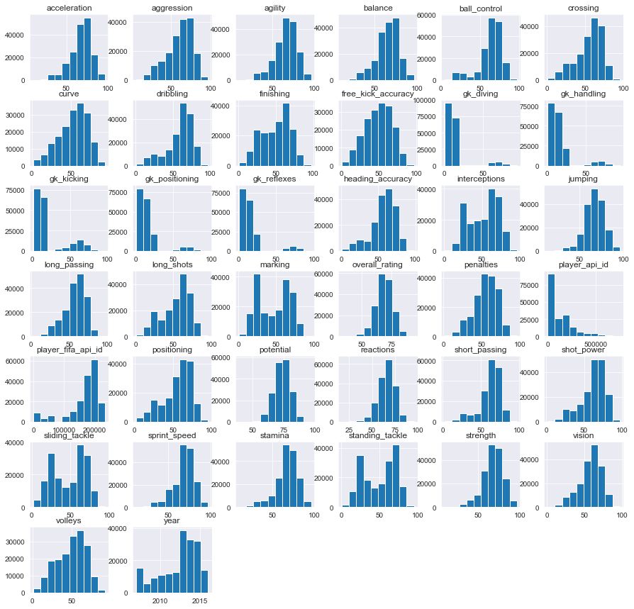

```python
# plot overview of data in player_df
player_df.hist(figsize=(15,15));
```

The above histograms were generated to get an overall sense of the *player_df* table

```python
# drop rows where selected columns below all contain null values
player_df.dropna(subset=['agility', 'balance', 'curve', 'jumping', 'vision', 'sliding_tackle', 'volleys'], how='all', inplace=True)
```

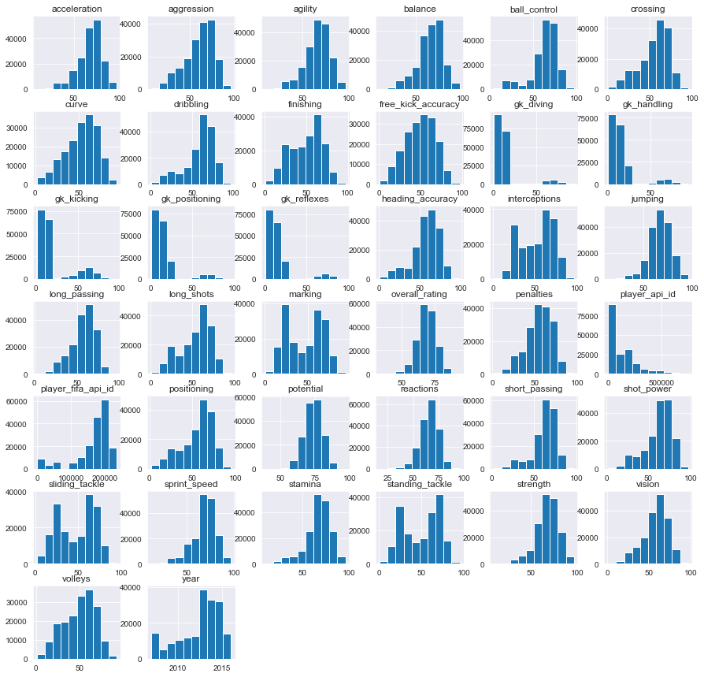

```python
#  plot overview of data in player_df with some null values dropped
player_df.hist(figsize=(15,15));
```

After dropping null values, and comparing with the graphs before dropping null values, we can see that there are no negligible differences.

```python
player_df.attacking_work_rate.value_counts()
```

```
medium    125070
high       42823
low         8569
None        3317
norm         317
y             94
stoc          86
le            78
Name: attacking_work_rate, dtype: int64
```

```python
# dropping columns below as they are not be pivotal in determining analysis of players, coupled with the fact that hundreds of values are not discernible
player_df.drop(columns=['attacking_work_rate', 'defensive_work_rate'], inplace=True)
```

```python
# check data after dropping null values and columns
player_df.info()
```

```
<class 'pandas.core.frame.DataFrame'>
Int64Index: 181265 entries, 0 to 183928
Data columns (total 41 columns):
player_name           181265 non-null object
player_fifa_api_id    181265 non-null int64
player_api_id         181265 non-null int64
date                  181265 non-null datetime64[ns]
overall_rating        181265 non-null float64
potential             181265 non-null float64
preferred_foot        181265 non-null object
crossing              181265 non-null float64
finishing             181265 non-null float64
heading_accuracy      181265 non-null float64
short_passing         181265 non-null float64
volleys               181265 non-null float64
dribbling             181265 non-null float64
curve                 181265 non-null float64
free_kick_accuracy    181265 non-null float64
long_passing          181265 non-null float64
ball_control          181265 non-null float64
acceleration          181265 non-null float64
sprint_speed          181265 non-null float64
agility               181265 non-null float64
reactions             181265 non-null float64
balance               181265 non-null float64
shot_power            181265 non-null float64
jumping               181265 non-null float64
stamina               181265 non-null float64
strength              181265 non-null float64
long_shots            181265 non-null float64
aggression            181265 non-null float64
interceptions         181265 non-null float64
positioning           181265 non-null float64
vision                181265 non-null float64
penalties             181265 non-null float64
marking               181265 non-null float64
standing_tackle       181265 non-null float64
sliding_tackle        181265 non-null float64
gk_diving             181265 non-null float64
gk_handling           181265 non-null float64
gk_kicking            181265 non-null float64
gk_positioning        181265 non-null float64
gk_reflexes           181265 non-null float64
year                  181265 non-null int64
dtypes: datetime64[ns](1), float64(35), int64(3), object(2)
memory usage: 58.1+ MB
```

### Clean data for 'Team' , 'Match' and 'Team Attributes' tables

```python
pd.set_option('display.max_rows', 500)
```

```python
matchteam_df.shape
```

```
(142076, 35)
```

```python
for i,v in enumerate(matchteam_df.columns):
    print(i,v)
```

```
0 league_id
1 season
2 date_m
3 match_api_id
4 home_team_api_id
5 away_team_api_id
6 home_team_goal
7 away_team_goal
8 team_id
9 home_team_name
10 id
11 team_fifa_api_id
12 team_api_id
13 date
14 buildUpPlaySpeed
```

[output cut: 20 more lines]

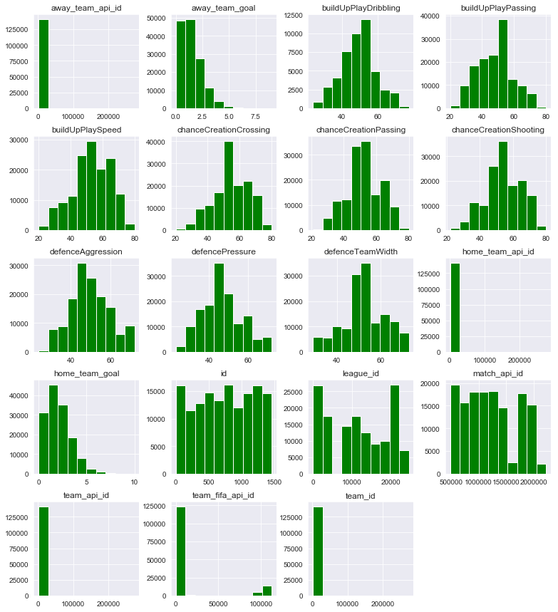

```python
# get a rough sense of matchteam_df data
matchteam_df.hist(color='green', figsize=(13,15));
```

The above histograms were generated to get an overall sense of the *matchteam_df* (Team, Team_Attributes & Match tables from original database) table

```python
matchteam_df.info()
```

```
<class 'pandas.core.frame.DataFrame'>
RangeIndex: 142076 entries, 0 to 142075
Data columns (total 35 columns):
league_id                         142076 non-null int64
season                            142076 non-null object
date_m                            142076 non-null object
match_api_id                      142076 non-null int64
home_team_api_id                  142076 non-null int64
away_team_api_id                  142076 non-null int64
home_team_goal                    142076 non-null int64
away_team_goal                    142076 non-null int64
team_id                           142076 non-null int64
home_team_name                    142076 non-null object
id                                142076 non-null int64
team_fifa_api_id                  142076 non-null int64
team_api_id                       142076 non-null int64
date                              142076 non-null object
buildUpPlaySpeed                  142076 non-null int64
buildUpPlaySpeedClass             142076 non-null object
buildUpPlayDribbling              47212 non-null float64
buildUpPlayDribblingClass         142076 non-null object
buildUpPlayPassing                142076 non-null int64
buildUpPlayPassingClass           142076 non-null object
buildUpPlayPositioningClass       142076 non-null object
chanceCreationPassing             142076 non-null int64
chanceCreationPassingClass        142076 non-null object
chanceCreationCrossing            142076 non-null int64
chanceCreationCrossingClass       142076 non-null object
chanceCreationShooting            142076 non-null int64
chanceCreationShootingClass       142076 non-null object
chanceCreationPositioningClass    142076 non-null object
defencePressure                   142076 non-null int64
defencePressureClass              142076 non-null object
defenceAggression                 142076 non-null int64
defenceAggressionClass            142076 non-null object
defenceTeamWidth                  142076 non-null int64
defenceTeamWidthClass             142076 non-null object
defenceDefenderLineClass          142076 non-null object
dtypes: float64(1), int64(18), object(16)
memory usage: 37.9+ MB
```

```python
# dropping 'buildUpPlayDribbling' column due to immense lack of data compared to the rest
matchteam_df.drop('buildUpPlayDribbling', axis=1, inplace=True)
```

```python
# check if any duplicated values
sum(matchteam_df.duplicated())
```

```
0
```

```python
# check for null values
matchteam_df.isnull().sum()
```

```
league_id                         0
season                            0
date_m                            0
match_api_id                      0
home_team_api_id                  0
away_team_api_id                  0
home_team_goal                    0
away_team_goal                    0
team_id                           0
home_team_name                    0
id                                0
team_fifa_api_id                  0
team_api_id                       0
date                              0
buildUpPlaySpeed                  0
buildUpPlaySpeedClass             0
buildUpPlayDribblingClass         0
buildUpPlayPassing                0
buildUpPlayPassingClass           0
buildUpPlayPositioningClass       0
chanceCreationPassing             0
chanceCreationPassingClass        0
chanceCreationCrossing            0
chanceCreationCrossingClass       0
chanceCreationShooting            0
chanceCreationShootingClass       0
chanceCreationPositioningClass    0
defencePressure                   0
defencePressureClass              0
defenceAggression                 0
defenceAggressionClass            0
defenceTeamWidth                  0
defenceTeamWidthClass             0
defenceDefenderLineClass          0
dtype: int64
```

## Exploratory Data Analysis

In this section, we will investigate the questions laid out in the introduction using clear visuals to put across the findings in a easy-to-understand manner.

### Which players had the most penalties?

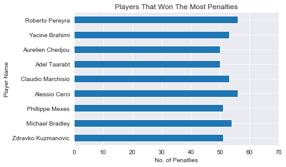

```python
# groupby both player_api_id & player_name in the event of 2 or more players having the same name
pen_count_df = player_df.groupby(['player_api_id', 'player_name']).penalties.count().reset_index()
# drop player_api_id column for plotting
pen_count_df.drop(['player_api_id'], axis=1, inplace=True)
# rename column for better readbility
pen_count_df.rename(columns={'penalties' : 'penalty_count'}, inplace=True)
# set player_name as index
pen_count_df.set_index('player_name', inplace=True)
# find top 0.01% penalty takers
pen_count_df[pen_count_df['penalty_count'] > pen_count_df.penalty_count.quantile(.999)].plot(kind='barh', xlim=(0,70), legend=False)
plt.title('Players That Won The Most Penalties')
plt.xlabel('No. of Penatlies')
plt.ylabel('Player Name')
plt.grid(True);
```

### Which players took the most accurate free-kicks?

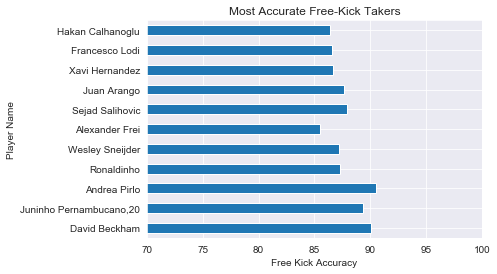

```python
# groupby both player_api_id & player_name in the event of 2 or more players having the same name
freekick_df = player_df.groupby(['player_api_id', 'player_name']).free_kick_accuracy.mean().reset_index()
# drop player_api_id column for plotting
freekick_df.drop(['player_api_id'], axis=1, inplace=True)
# set player_name as index
freekick_df.set_index('player_name', inplace=True)
freekick_df
# find top 0.01% free-kick takers
freekick_df[freekick_df['free_kick_accuracy'] > freekick_df.free_kick_accuracy.quantile(.999)].plot(kind='barh', xlim=(70,100), legend=False)
plt.title('Most Accurate Free-Kick Takers')
plt.xlabel('Free Kick Accuracy')
plt.ylabel('Player Name')
plt.grid(True);
```

Based on the above findings, we can see that the most accurate free kick taker was Andrea Pirlo, followed by David Beckham (which is personally surprising for me).

### Which teams had the most victories at home in the 2015/2016 season?

```python
pd.set_option('display.max_columns', 50)
matchteam_df.head(2)
```

|  | league_id | season | date_m | match_api_id | home_team_api_id | away_team_api_id | home_team_goal | away_team_goal | team_id | home_team_name | id | team_fifa_api_id | team_api_id | date | buildUpPlaySpeed | buildUpPlaySpeedClass | buildUpPlayDribblingClass | buildUpPlayPassing | buildUpPlayPassingClass | buildUpPlayPositioningClass | chanceCreationPassing | chanceCreationPassingClass | chanceCreationCrossing | chanceCreationCrossingClass | chanceCreationShooting | chanceCreationShootingClass | chanceCreationPositioningClass | defencePressure | defencePressureClass | … |
| --- | --- | --- | --- | --- | --- | --- | --- | --- | --- | --- | --- | --- | --- | --- | --- | --- | --- | --- | --- | --- | --- | --- | --- | --- | --- | --- | --- | --- | --- | --- |
| 0 | 15722 | 2008/2009 | 2008-08-16 00:00:00 | 506549 | 1601 | 8030 | 2 | 1 | 1601 | Ruch Chorzów | 1113 | 874 | 1601 | 2010-02-22 00:00:00 | 30 | Slow | Little | 40 | Mixed | Organised | 50 | Normal | 35 | Normal | 70 | Lots | Organised | 65 | Medium | … |
| 1 | 15722 | 2008/2009 | 2008-08-16 00:00:00 | 506549 | 1601 | 8030 | 2 | 1 | 1601 | Ruch Chorzów | 1114 | 874 | 1601 | 2011-02-22 00:00:00 | 48 | Balanced | Little | 51 | Mixed | Organised | 68 | Risky | 67 | Lots | 51 | Normal | Organised | 46 | Medium | … |

```python
# create an 'outcome' column to track teams' performance
matchteam_df['outcome'] = np.where(matchteam_df.home_team_goal > matchteam_df.away_team_goal,'win','lose')
matchteam_df.loc[matchteam_df.home_team_goal == matchteam_df.away_team_goal, 'outcome'] = 'draw'
matchteam_df.head()
```

|  | league_id | season | date_m | match_api_id | home_team_api_id | away_team_api_id | home_team_goal | away_team_goal | team_id | home_team_name | id | team_fifa_api_id | team_api_id | date | buildUpPlaySpeed | buildUpPlaySpeedClass | buildUpPlayDribblingClass | buildUpPlayPassing | buildUpPlayPassingClass | buildUpPlayPositioningClass | chanceCreationPassing | chanceCreationPassingClass | chanceCreationCrossing | chanceCreationCrossingClass | chanceCreationShooting | chanceCreationShootingClass | chanceCreationPositioningClass | defencePressure | defencePressureClass | … |
| --- | --- | --- | --- | --- | --- | --- | --- | --- | --- | --- | --- | --- | --- | --- | --- | --- | --- | --- | --- | --- | --- | --- | --- | --- | --- | --- | --- | --- | --- | --- |
| 0 | 15722 | 2008/2009 | 2008-08-16 00:00:00 | 506549 | 1601 | 8030 | 2 | 1 | 1601 | Ruch Chorzów | 1113 | 874 | 1601 | 2010-02-22 00:00:00 | 30 | Slow | Little | 40 | Mixed | Organised | 50 | Normal | 35 | Normal | 70 | Lots | Organised | 65 | Medium | … |
| 1 | 15722 | 2008/2009 | 2008-08-16 00:00:00 | 506549 | 1601 | 8030 | 2 | 1 | 1601 | Ruch Chorzów | 1114 | 874 | 1601 | 2011-02-22 00:00:00 | 48 | Balanced | Little | 51 | Mixed | Organised | 68 | Risky | 67 | Lots | 51 | Normal | Organised | 46 | Medium | … |
| 2 | 15722 | 2008/2009 | 2008-08-16 00:00:00 | 506549 | 1601 | 8030 | 2 | 1 | 1601 | Ruch Chorzów | 1115 | 874 | 1601 | 2012-02-22 00:00:00 | 53 | Balanced | Little | 55 | Mixed | Organised | 44 | Normal | 65 | Normal | 50 | Normal | Organised | 43 | Medium | … |
| 3 | 15722 | 2008/2009 | 2008-08-16 00:00:00 | 506549 | 1601 | 8030 | 2 | 1 | 1601 | Ruch Chorzów | 1116 | 874 | 1601 | 2013-09-20 00:00:00 | 53 | Balanced | Little | 55 | Mixed | Organised | 44 | Normal | 65 | Normal | 50 | Normal | Organised | 43 | Medium | … |
| 4 | 15722 | 2008/2009 | 2008-08-16 00:00:00 | 506549 | 1601 | 8030 | 2 | 1 | 1601 | Ruch Chorzów | 1117 | 874 | 1601 | 2014-09-19 00:00:00 | 53 | Balanced | Normal | 38 | Mixed | Organised | 66 | Normal | 65 | Normal | 50 | Normal | Organised | 43 | Medium | … |

```python
# filter for 2015/2016 season only
season_1516 = matchteam_df[matchteam_df['season'] == '2015/2016']
season_1516.head()
```

|  | league_id | season | date_m | match_api_id | home_team_api_id | away_team_api_id | home_team_goal | away_team_goal | team_id | home_team_name | id | team_fifa_api_id | team_api_id | date | buildUpPlaySpeed | buildUpPlaySpeedClass | buildUpPlayDribblingClass | buildUpPlayPassing | buildUpPlayPassingClass | buildUpPlayPositioningClass | chanceCreationPassing | chanceCreationPassingClass | chanceCreationCrossing | chanceCreationCrossingClass | chanceCreationShooting | chanceCreationShootingClass | chanceCreationPositioningClass | defencePressure | defencePressureClass | … |
| --- | --- | --- | --- | --- | --- | --- | --- | --- | --- | --- | --- | --- | --- | --- | --- | --- | --- | --- | --- | --- | --- | --- | --- | --- | --- | --- | --- | --- | --- | --- |
| 124686 | 15722 | 2015/2016 | 2015-07-18 00:00:00 | 1994618 | 1601 | 8019 | 0 | 2 | 1601 | Ruch Chorzów | 1113 | 874 | 1601 | 2010-02-22 00:00:00 | 30 | Slow | Little | 40 | Mixed | Organised | 50 | Normal | 35 | Normal | 70 | Lots | Organised | 65 | Medium | … |
| 124687 | 15722 | 2015/2016 | 2015-07-18 00:00:00 | 1994618 | 1601 | 8019 | 0 | 2 | 1601 | Ruch Chorzów | 1114 | 874 | 1601 | 2011-02-22 00:00:00 | 48 | Balanced | Little | 51 | Mixed | Organised | 68 | Risky | 67 | Lots | 51 | Normal | Organised | 46 | Medium | … |
| 124688 | 15722 | 2015/2016 | 2015-07-18 00:00:00 | 1994618 | 1601 | 8019 | 0 | 2 | 1601 | Ruch Chorzów | 1115 | 874 | 1601 | 2012-02-22 00:00:00 | 53 | Balanced | Little | 55 | Mixed | Organised | 44 | Normal | 65 | Normal | 50 | Normal | Organised | 43 | Medium | … |
| 124689 | 15722 | 2015/2016 | 2015-07-18 00:00:00 | 1994618 | 1601 | 8019 | 0 | 2 | 1601 | Ruch Chorzów | 1116 | 874 | 1601 | 2013-09-20 00:00:00 | 53 | Balanced | Little | 55 | Mixed | Organised | 44 | Normal | 65 | Normal | 50 | Normal | Organised | 43 | Medium | … |
| 124690 | 15722 | 2015/2016 | 2015-07-18 00:00:00 | 1994618 | 1601 | 8019 | 0 | 2 | 1601 | Ruch Chorzów | 1117 | 874 | 1601 | 2014-09-19 00:00:00 | 53 | Balanced | Normal | 38 | Mixed | Organised | 66 | Normal | 65 | Normal | 50 | Normal | Organised | 43 | Medium | … |

```python
# groupby team name so we can aggregate total number of wins & losses
most_wins = season_1516.groupby(['home_team_name']).outcome.describe().reset_index()
most_wins.head(8)
```

|  | home_team_name | count | unique | top | freq |
| --- | --- | --- | --- | --- | --- |
| 0 | 1. FC Köln | 102 | 3 | lose | 42 |
| 1 | 1. FSV Mainz 05 | 102 | 3 | win | 48 |
| 2 | ADO Den Haag | 102 | 3 | draw | 48 |
| 3 | AS Monaco | 114 | 3 | win | 60 |
| 4 | AS Saint-Étienne | 114 | 3 | win | 60 |
| 5 | AZ | 102 | 3 | win | 60 |
| 6 | Aberdeen | 114 | 3 | win | 72 |
| 7 | Académica de Coimbra | 102 | 3 | lose | 42 |

```python
# create filters
win = most_wins.top == 'win'
lose = most_wins.top == 'lose'
```

```python
# filter for top 10 winning teams
best_teams = most_wins[win].sort_values(by='freq', ascending=False).head(10).set_index('home_team_name')
best_teams
```

| home_team_name | count | unique | top | freq |
| --- | --- | --- | --- | --- |
| Napoli | 114 | 2 | win | 96 |
| FC Barcelona | 114 | 3 | win | 96 |
| Juventus | 114 | 3 | win | 96 |
| Real Madrid CF | 114 | 3 | win | 96 |
| SL Benfica | 102 | 2 | win | 90 |
| FC Bayern Munich | 102 | 3 | win | 90 |
| Atlético Madrid | 114 | 3 | win | 90 |
| Paris Saint-Germain | 114 | 3 | win | 90 |
| Borussia Dortmund | 102 | 2 | win | 84 |
| Sevilla FC | 114 | 3 | win | 84 |

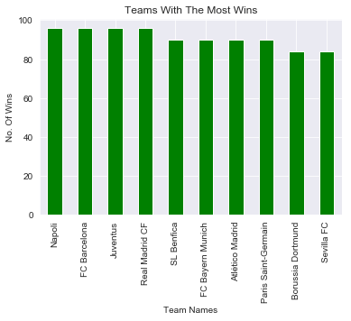

```python
# clean up above dataframe for plotting
best_teams.drop(columns=['count', 'unique', 'top']).plot(kind='bar', color='green',legend=False)
plt.title('Teams With The Most Wins')
plt.xlabel('Team Names')
plt.ylabel('No. Of Wins')
plt.grid();
```

From the above table & can see that there is a tie in most wins for season 2015/2016. Limitations of the above is not having consistent number of records represented for all teams, hence, teams like FC Bayern Munich might not have more wins than in actual fact.

### What team attributes led to the most victories?

```python
matchteam_df.head()
```

|  | league_id | season | date_m | match_api_id | home_team_api_id | away_team_api_id | home_team_goal | away_team_goal | team_id | home_team_name | id | team_fifa_api_id | team_api_id | date | buildUpPlaySpeed | buildUpPlaySpeedClass | buildUpPlayDribblingClass | buildUpPlayPassing | buildUpPlayPassingClass | buildUpPlayPositioningClass | chanceCreationPassing | chanceCreationPassingClass | chanceCreationCrossing | chanceCreationCrossingClass | chanceCreationShooting | chanceCreationShootingClass | chanceCreationPositioningClass | defencePressure | defencePressureClass | … |
| --- | --- | --- | --- | --- | --- | --- | --- | --- | --- | --- | --- | --- | --- | --- | --- | --- | --- | --- | --- | --- | --- | --- | --- | --- | --- | --- | --- | --- | --- | --- |
| 0 | 15722 | 2008/2009 | 2008-08-16 00:00:00 | 506549 | 1601 | 8030 | 2 | 1 | 1601 | Ruch Chorzów | 1113 | 874 | 1601 | 2010-02-22 00:00:00 | 30 | Slow | Little | 40 | Mixed | Organised | 50 | Normal | 35 | Normal | 70 | Lots | Organised | 65 | Medium | … |
| 1 | 15722 | 2008/2009 | 2008-08-16 00:00:00 | 506549 | 1601 | 8030 | 2 | 1 | 1601 | Ruch Chorzów | 1114 | 874 | 1601 | 2011-02-22 00:00:00 | 48 | Balanced | Little | 51 | Mixed | Organised | 68 | Risky | 67 | Lots | 51 | Normal | Organised | 46 | Medium | … |
| 2 | 15722 | 2008/2009 | 2008-08-16 00:00:00 | 506549 | 1601 | 8030 | 2 | 1 | 1601 | Ruch Chorzów | 1115 | 874 | 1601 | 2012-02-22 00:00:00 | 53 | Balanced | Little | 55 | Mixed | Organised | 44 | Normal | 65 | Normal | 50 | Normal | Organised | 43 | Medium | … |
| 3 | 15722 | 2008/2009 | 2008-08-16 00:00:00 | 506549 | 1601 | 8030 | 2 | 1 | 1601 | Ruch Chorzów | 1116 | 874 | 1601 | 2013-09-20 00:00:00 | 53 | Balanced | Little | 55 | Mixed | Organised | 44 | Normal | 65 | Normal | 50 | Normal | Organised | 43 | Medium | … |
| 4 | 15722 | 2008/2009 | 2008-08-16 00:00:00 | 506549 | 1601 | 8030 | 2 | 1 | 1601 | Ruch Chorzów | 1117 | 874 | 1601 | 2014-09-19 00:00:00 | 53 | Balanced | Normal | 38 | Mixed | Organised | 66 | Normal | 65 | Normal | 50 | Normal | Organised | 43 | Medium | … |

```python
# filter top teams to find out what attributes were important in achieving their victories
alltime_best_teams = matchteam_df.groupby(['home_team_name']).outcome.describe().sort_values(by='freq',ascending=False).reset_index()
alltime_best_teams.head()
```

|  | home_team_name | count | unique | top | freq |
| --- | --- | --- | --- | --- | --- |
| 0 | FC Barcelona | 912 | 3 | win | 786 |
| 1 | Real Madrid CF | 912 | 3 | win | 774 |
| 2 | Celtic | 912 | 3 | win | 720 |
| 3 | Manchester United | 912 | 3 | win | 696 |
| 4 | Manchester City | 912 | 3 | win | 678 |

```python
# filter further for top 10 teams only
top_best_teams = alltime_best_teams.home_team_name.head(10)
# query for top 10 teams in the main dataframe(matchteam_df)
new_matchteam_df = matchteam_df.query('home_team_name in @top_best_teams')
new_matchteam_df.head()
```

|  | league_id | season | date_m | match_api_id | home_team_api_id | away_team_api_id | home_team_goal | away_team_goal | team_id | home_team_name | id | team_fifa_api_id | team_api_id | date | buildUpPlaySpeed | buildUpPlaySpeedClass | buildUpPlayDribblingClass | buildUpPlayPassing | buildUpPlayPassingClass | buildUpPlayPositioningClass | chanceCreationPassing | chanceCreationPassingClass | chanceCreationCrossing | chanceCreationCrossingClass | chanceCreationShooting | chanceCreationShootingClass | chanceCreationPositioningClass | defencePressure | defencePressureClass | … |
| --- | --- | --- | --- | --- | --- | --- | --- | --- | --- | --- | --- | --- | --- | --- | --- | --- | --- | --- | --- | --- | --- | --- | --- | --- | --- | --- | --- | --- | --- | --- |
| 2917 | 1729 | 2008/2009 | 2008-08-24 00:00:00 | 489055 | 8456 | 8654 | 3 | 0 | 8456 | Manchester City | 801 | 10 | 8456 | 2010-02-22 00:00:00 | 70 | Fast | Little | 60 | Mixed | Organised | 55 | Normal | 70 | Lots | 70 | Lots | Organised | 45 | Medium | … |
| 2918 | 1729 | 2008/2009 | 2008-08-24 00:00:00 | 489055 | 8456 | 8654 | 3 | 0 | 8456 | Manchester City | 802 | 10 | 8456 | 2011-02-22 00:00:00 | 70 | Fast | Little | 60 | Mixed | Organised | 70 | Risky | 65 | Normal | 75 | Lots | Free Form | 65 | Medium | … |
| 2919 | 1729 | 2008/2009 | 2008-08-24 00:00:00 | 489055 | 8456 | 8654 | 3 | 0 | 8456 | Manchester City | 803 | 10 | 8456 | 2012-02-22 00:00:00 | 45 | Balanced | Little | 55 | Mixed | Organised | 40 | Normal | 38 | Normal | 48 | Normal | Free Form | 50 | Medium | … |
| 2920 | 1729 | 2008/2009 | 2008-08-24 00:00:00 | 489055 | 8456 | 8654 | 3 | 0 | 8456 | Manchester City | 804 | 10 | 8456 | 2013-09-20 00:00:00 | 36 | Balanced | Little | 34 | Mixed | Organised | 39 | Normal | 44 | Normal | 38 | Normal | Free Form | 42 | Medium | … |
| 2921 | 1729 | 2008/2009 | 2008-08-24 00:00:00 | 489055 | 8456 | 8654 | 3 | 0 | 8456 | Manchester City | 805 | 10 | 8456 | 2014-09-19 00:00:00 | 59 | Balanced | Normal | 29 | Short | Organised | 32 | Safe | 49 | Normal | 62 | Normal | Organised | 42 | Medium | … |

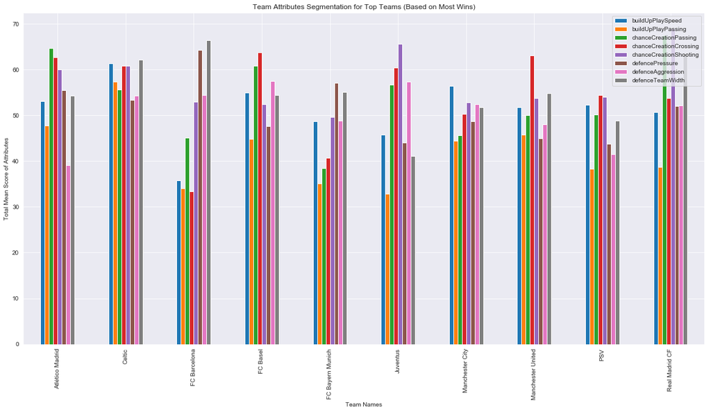

```python
attributes_table = new_matchteam_df[['home_team_name','buildUpPlaySpeed', 'buildUpPlayPassing', 'chanceCreationPassing', 'chanceCreationCrossing','chanceCreationShooting','defencePressure', 'defenceAggression', 'defenceTeamWidth']]
attributes_table.groupby('home_team_name').mean().plot.bar(figsize=(20,10))
plt.legend(loc='best')
plt.title('Team Attributes Segmentation for Top Teams (Based on Most Wins)')
plt.xlabel('Team Names')
plt.ylabel('Total Mean Score of Attributes')
plt.grid(True);
```

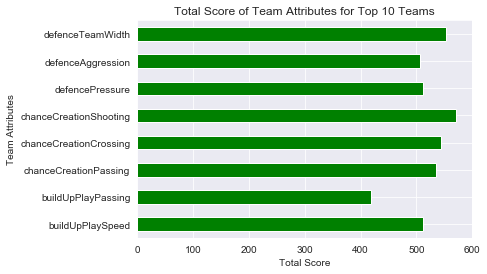

```python
attributes_table.groupby('home_team_name').mean().sum().plot.barh(color='green')
plt.title('Total Score of Team Attributes for Top 10 Teams')
plt.ylabel('Team Attributes')
plt.xlabel('Total Score')
plt.grid(True);
```

```python
print('Top Team Attribute: ' + str(attributes_table.groupby('home_team_name').mean().sum().idxmax()))
print('Score: '  + str(attributes_table.groupby('home_team_name').mean().sum().max()))
```

```
Top Team Attribute: chanceCreationShooting
Score: 571.3333333333333
```

It is hard to see from the bar plot above which team attributes contribute to the most wins. However, the most common team attribute across all top 10 teams is the *'Chance Creation Shooting'* attribute, with all teams having a minimum mean score of 49 and above.

## Conclusions

> In the beginning I posted the questions to answer matters about an individual player to the overall team. It was interesting to find out what team attributes led to the most wins.

> With all that mentioned, there are certainly limitations to the data set, with a handful teams not having full records, and most teams missing data here and there for different years that would make a difference in gathering the top 10 teams. I am not a 100% sure on whether the way I have pulled the data with my SQL queries were what was best as well *(eg. could have been unneccesary dupilicates etc.)*

> I believe I could have expressed the visualisations in a clearer manner with different kind of plots which I have yet to learn, and draw correlations more easily & quickly.